# Exploring impacts of reducing assessment frequency for BSAI Flathead Sole Complex

M Sosa Kapur maia.kapur@noaa.gov

*Material presented in this document should not be considered final*.

In late May 2022 members of the SSMA were asked to produce runs producing ABC/OFLs for BSAI stocks “as if” assessment occurred only every 2 or 4 years. The BSAI FHS complex was last fully assessed in 2020 by C Monnohan.

This analysis uses the following assumptions and approaches:

- All runs are done using versions of the most recent benchmark assessment model conducted by C. Monnohan in 2020. This means that management quantities are products of that assessment model, and we would *not* expect them to exactly reproduce the values actually used for management in earlier years (since those assessments had different model configurations, and also had to estimate in-year catch data). Therefore, *values in this document should not be compared to those on the Federal Register*.
- Relatedly, all simulated assessments in this analysis retained the parameterization from the 2020 model (i.e. no change to which parameters were estimated, nor the values at which they are fixed, both of which might affect model outcomes). The 2020 model was itself unchanged from 2018.
- We focused on four- and two-year assessment intervals beginning in 2008. We ran a retrospective routine which truncates the data and the final year of model dynamics. This approach does *not* update (reverse) the terminal year of recruitment bias adjustment, which in 2020 was set at 2015.8.
- The `proj` model was used to get inter-benchmark reference points using the most recent benchmark model and the true observed catch from those years. For example, the four-year analysis conducts a full assessment in 2008, then an update assessment (`proj` model only) for years 2009-2011, here using true catch observations, before another full assessment in 2012. The two-year analysis would instead do a full assessment in 2010, which would be used in a `proj` model in 2011, etc.
- The figures present one-year-ahead projections only, i.e. ABC/OFLs from the full assessment done in 2008 are shown for year 2009; values for 2010 come from the projection-only model from 2009, etc.
- Based on this quick analysis, there do not appear to be strong impacts in the period analyzed and given the assumptions at the beginning of this document. There are no changes in either management quantity (ABC or OFL) greater than 8%. At present, this accounts for roughly 5000 mt of catch; note that the average catch over the modeled period has been less than 10,000, while attainment (catch/TAC has been on the order of <25%.)

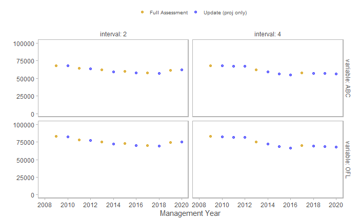

[output not shown]

The percent change in ABCs and OFLs between frequencies are presented in the following table. Values are calculated as $\frac{OFL_{y, freq=4}-OFL_{y, freq=2}}{OFL_{y, freq=2}}$.

| refYr | 2 year ABC | 4 year ABC | 2 year OFL | 4 year OFL | ABC_pDiff | OFL_pDiff |
| --- | --- | --- | --- | --- | --- | --- |
| 2009 | 68326.4 | 68326.5 | 82765.5 | 82765.6 | 0% | 0% |
| 2010 | 68041.0 | 68040.9 | 82439.6 | 82439.5 | 0% | 0% |
| 2011 | 64321.7 | 67503.4 | 77910.5 | 81789.0 | 4.9% | 5% |
| 2012 | 63618.2 | 67544.6 | 77032.4 | 81816.5 | 6.2% | 6.2% |
| 2013 | 62013.9 | 62014.0 | 75068.8 | 75068.9 | 0% | 0% |
| 2014 | 59365.1 | 59364.9 | 71837.3 | 71837.1 | 0% | 0% |
| 2015 | 59917.5 | 56679.8 | 72591.8 | 68574.7 | -5.4% | -5.5% |
| 2016 | 57772.0 | 55089.0 | 69976.1 | 66649.7 | -4.6% | -4.8% |
| 2017 | 58085.6 | 58085.7 | 70312.5 | 70312.6 | 0% | 0% |
| 2018 | 57274.7 | 57274.7 | 69349.9 | 69349.9 | 0% | 0% |

[output cut: 1 more lines]